# Part II - (Ford Gobike System Data Exploration)

## by (Samantha Erskine)

## Investigation Overview

> In this section, I will highlight one of my features of interest, which is seen to be the age group of members, and how this feature shows more insight as it is compared against other features which are the duration of bike rides in minutes and the user type. This will be shown in three visualizations, one univariate, one bivariate and one multivariate.

## (Visualization 1)

> This univariate visualization shows distribution of the age of members in the go bike Ford share system. This histogram shows the distribution of riders and most riders are between the ages of 25 and 35, while the least amount of riders in terms of age, are those older than 75.

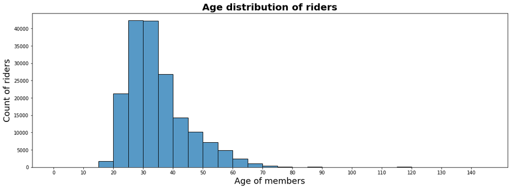

## (Visualization 2)

> This bivariate visualization shows the relationship between the age of members and the duration in minutes, that each person rode. The scatter plot indicates a relationship between the age of members and the duration of minutes in which they rode the ford go bikes. It indicates that people aged between 20 and 60 rode bikes up to 200 minutes and a fewer number of them drove past the 200 minute mark up to 1400 minutes. Above 60 years of age, fewer people ride for a fewer number of minutes. This means there is a negative correlation between the age of members and the number of minutes they ride the bike. It also shows there are a small amount of people who ride aged above 80.

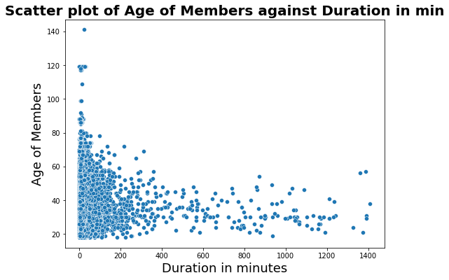

## (Visualization 3)

> This final multivariate visualization shows the relationship between the age of members, the user type they opted for and the duration of minutes in which the bikes were ridden.

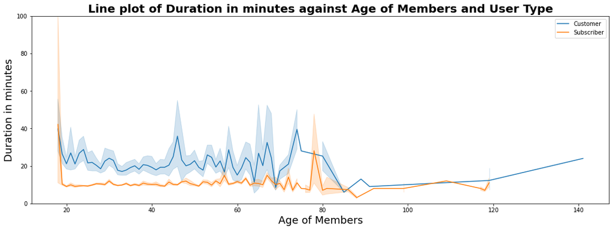